# Регрессия

$X$ - пространство объектов;  
$Y\in \mathcal{R}$ - пространство ответов;  
$y: X \rightarrow Y$ - неизвестная функция.

**Дано:**  
$\{x_1, \ldots, x_l\}\subset X$ - обучающая выборка (training sample);  
$y_i=y(x_i), i=1,\ldots,l$ - известные ответы.

**Найти:**  
$a: X \rightarrow Y$ - алгоритм, приближающий $y$ на всем множестве $X$.

#### Пример линейной регрессии

[figure not shown]

$$ price = a * square + b + \varepsilon $$

$$ y = ax + b + \varepsilon $$

$$ \sum_{i=1}^l(y_i - ax_i - b)^2\rightarrow\min_{a, b} $$

Задача на нахождение глобального минимума.

$$ a = \frac{\overline{xy} - \overline{x}\overline{y}}{\overline{x^2} - \overline{x}^2} $$$$ b = \overline{y} - a\overline{x} $$

[figure not shown]

#### Общий случай

Матрица "объекты-признаки" $$ X = \begin{pmatrix} f_1(x_1) & \ldots & f_n(x_1) \\ \ldots & \ldots & \ldots \\ f_1(x_l) & \ldots & f_n(x_l) \end{pmatrix} $$ Вектор истинных ответов $$ y = \begin{pmatrix} y_1 \\ \ldots \\ y_l \end{pmatrix} $$ Вектор коэффициентов модели $$ \alpha = \begin{pmatrix} \alpha_1 \\ \ldots \\ \alpha_n \end{pmatrix} $$

$$ Q(a, X^l)=\sum_{i=1}^l\big(f(x_i, \alpha)-y_i\big)^2 = \big|\big|X\alpha -y\big|\big|^2\rightarrow\min_\alpha $$

$$ \frac{\partial Q}{\partial \alpha}(\alpha)=2X^T(X\alpha-y)=0 $$

$$ X^TX\alpha=X^Ty $$

$$ \alpha^* = (X^TX)^{-1}X^Ty=X^+y $$

Проблема в том, что $X^TX$ может быть плохо обратима.

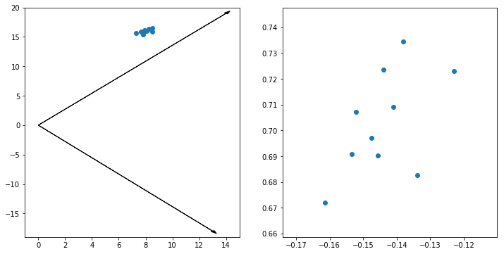

```python
A = np.array([
    [13, 14],
    [-18, 19]
])
plot_solution(A)
```

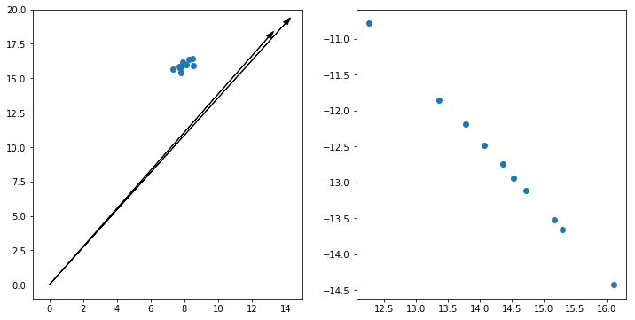

```python
A = np.array([
    [13, 14],
    [18, 19]
])
plot_solution(A)
```

$$ X^+ = (USV^TVSU^T)^{-1}USV^T=US^{-1}V^T=\sum_{j=1}^n\frac{1}{\sqrt{\lambda_j}}u_jv_j^T $$$$ \alpha^* = X^+y = US^{-1}V^Ty=\sum_{j=1}^n\frac{1}{\sqrt{\lambda_j}}u_j(v_j^Ty) $$$$ \big|\big|\alpha^*\big|\big|^2 = \big|\big|S^{-1}V^Ty\big|\big|^2 =\sum_{j=1}^n\frac{1}{\lambda_j}(v_j^Ty)^2 $$

Число обусловленности

$$ \mu(S) = \frac{\lambda_\max}{\lambda_\min} $$

Если матрица $C=X^TX$ плохо обусловлена, то:

1) решение неустойчиво и плохо интерпретируемо;  
2) $\big|\big|\alpha^*\big|\big|$ велико;  
3) возникает переобучение.

Решение проблемы:

1) регуляризация: $\big|\big|\alpha\big|\big|\rightarrow\min$;  
2) отбор признаков: $f_1, \ldots, f_n\rightarrow f_{j_1},\ldots, f_{j_m}$, $m\ll n$;  
3) преобразование признаков: $f_1,\ldots,f_n\rightarrow g_1, \ldots, g_m$, $m\ll n$.

## Регуляризация

Вместо

$$ Q(a, X^l)= \big|\big|X\alpha -y\big|\big|^2\rightarrow\min_\alpha $$

будем рассматривать

$$ Q(a, X^l)= \big|\big|X\alpha -y\big|\big|^2 + \lambda\big|\big|\alpha\big|\big|^2\rightarrow\min_\alpha $$

Тогда вместо

$$ \big|\big|\alpha^*\big|\big|^2 = \big|\big|S^{-1}V^Ty\big|\big|^2 =\sum_{j=1}^n\frac{1}{\lambda_j}(v_j^Ty)^2 $$

получим

$$ \big|\big|\alpha^*\big|\big|^2 = \big|\big|(S^2+\tau I_n)^{-1}SV^Ty\big|\big|^2 =\sum_{j=1}^n\frac{\lambda_j}{(\lambda_j+\tau)^2}(v_j^Ty)^2 $$

#### Виды регуляризации

- [Ridge](http://scikit-learn.org/stable/modules/generated/sklearn.linear_model.Ridge.html) $$ Q(a, X^l)= \big|\big|X\alpha -y\big|\big|^2 + \lambda\big|\big|\alpha\big|\big|_2^2\rightarrow\min_\alpha $$
- [Lasso](http://scikit-learn.org/stable/modules/generated/sklearn.linear_model.Lasso.html) $$ Q(a, X^l)= \big|\big|X\alpha -y\big|\big|^2 + \lambda\big|\big|\alpha\big|\big|_1\rightarrow\min_\alpha $$
- [ElasticNet](http://scikit-learn.org/stable/modules/generated/sklearn.linear_model.ElasticNet.html) $$ Q(a, X^l)= \big|\big|X\alpha -y\big|\big|^2 + \lambda\big(\beta\big|\big|\alpha\big|\big|_2^2 + (1-\beta) \big|\big|\alpha\big|\big|_1\big)\rightarrow\min_\alpha, \beta\in[0, 1] $$

**Ridge**

[figure not shown]

**Lasso**

[figure not shown]

**Ridge**

Вместо

$$ Q(a, X^l)= \big|\big|X\alpha -y\big|\big|^2 + \lambda\big|\big|\alpha\big|\big|_2^2\rightarrow\min_\alpha $$

можно рассматривать

$$ \begin{cases} Q(a, X^l)= \big|\big|X\alpha -y\big|\big|^2 \rightarrow \min_\alpha \\ \big|\big|\alpha\big|\big|_2^2 \lt \eta \end{cases} $$

**Lasso**

Вместо

$$ Q(a, X^l)= \big|\big|X\alpha -y\big|\big|^2 + \lambda\big|\big|\alpha\big|\big|_1\rightarrow\min_\alpha $$

можно рассматривать

$$ \begin{cases} Q(a, X^l)= \big|\big|X\alpha -y\big|\big|^2 \rightarrow \min_\alpha \\ \big|\big|\alpha\big|\big|_1 \lt \eta \end{cases} $$

[figure not shown]

## Оценка качества работы регрессионной модели

#### Линейная зависимость

[figure not shown]

$\bar{y}$ - среднее значение, $\hat{y}_i$ - моделируемое значение, $y_i$ - наблюдаемое значение.

#### Объясненная и необъясненная дисперсия

**SST** = *total sum of squares*  
сумма квадратов отклонений наблюдений от среднего значения наблюдений

**SSE** = *error sum of squares*  
сумма квадратов отклонений наблюдений от моделируемых значений

**SSR** = *regression sum of squares*  
сумма квадратов отклонений моделируемых значений от среднего значения наблюдений

Коэффициент определенности (R-squared)

$$ R^2 = \frac{SSR}{SST} $$

[figure not shown]

## Полиномиальная регрессия

**Пример**

[figure not shown]

В качестве признаков можно иcпользовать $f_i^2(x_k),\ f_i^3(x_k),\ f_i(x_k)f_j(x_k),\ \ldots$ - произведения степеней признаков.

[Реализация](http://scikit-learn.org/stable/modules/generated/sklearn.preprocessing.PolynomialFeatures.html#sklearn.preprocessing.PolynomialFeatures)

Можно добавлять и другие признаки: sin, cos, exp, log, ...

**Полиномиальная регрессия степени 2**

[figure not shown]

**Полиномиальная регрессия степени 5**

[figure not shown]

**Полиномиальная регрессия степени 5**

[figure not shown]

Переобучение!

**Полиномиальная регрессия степени 5 с регуляризацией**

[figure not shown]

## Прочие алгоритмы регрессии

[SVM](http://scikit-learn.org/stable/modules/generated/sklearn.svm.SVR.html)

[figure not shown]

Штрафуем за выход из "трубки".

$$ h_\varepsilon(x)= \begin{cases} 0, &\text{if}\ |x|<\varepsilon \\ |x|, &\text{else} \end{cases} $$$$ C\sum_{i=1}^lh_\varepsilon(\xi_- + \xi_+)+\frac{1}{2}||w||^2 \rightarrow \min_{w,w_0}, $$

где $\xi_-$ - отступ ниже линии, $\xi_+$ - отступ выше линии.

[kNN](http://scikit-learn.org/stable/modules/generated/sklearn.neighbors.KNeighborsRegressor.html)

Берем среднее значение по соседям.

[Decision Tree](http://scikit-learn.org/stable/modules/generated/sklearn.tree.DecisionTreeRegressor.html)

Берем среднее значение по элементам обучающей выборки, попавшей в лист.

[Random Forest](http://scikit-learn.org/stable/modules/generated/sklearn.ensemble.RandomForestRegressor.html)

Берем среднее значение по предсказаниям каждого дерева.